# OSHA Exploratory Analysis

Setup - Import libraries

```r
library(feather)    # for data storage
library(stringr)    # for string manipulation
library(readxl)     # for Excel import
library(lubridate)  # for date manipulation
library(scales)     # for pretty printing
library(tidyverse)  # misc
library(forcats)    # easier factor manipulation
```

The OSHA data can be found at http://ogesdw.dol.gov/views/data_summary.php.

# Convert Data

We’ve downloaded five data files matching with the tables in the data challenge and placed them in the `data` subdirectory. Now we load them in from CSVs using the `readr` package, which is a faster and more intelligent CSV importer than the base version.

```r
inspect <- read_csv("./data/osha_inspection.csv")
strat_codes <- read_csv("./data/osha_strategic_codes.csv")
optional_info <- read_csv("./data/osha_optional_info.csv")
related_activity <- read_csv("./data/osha_related_activity.csv")
violations <- read_csv("./data/osha_violation.csv")
```

Perform some data type munging on the loaded data set, per the data dictionary and exploration.

```r
related_activity %>% mutate(rel_health = ifelse("X", TRUE, FALSE),
                            rel_safety = ifelse("X", TRUE, FALSE)))
```

```r
write_feather(inspect, "./data/osha_inspection.feather")
write_feather(violations, "./data/osha_violation.feather")
write_feather(strat_codes, "./data/osha_strategic_codes.feather")
write_feather(optional_info, "./data/osha_optional_info.feather")
write_feather(related_activity, "./data/osha_related_activity.feather")
```

```r
inspect <- read_feather("./data/osha_inspection.feather")
strat_codes <- read_feather("./data/osha_strategic_codes.feather")
optional_info <- read_feather("./data/osha_optional_info.feather")
related_activity <- read_feather("./data/osha_related_activity.feather")
violations <- read_feather("./data/osha_violation.feather")
```

The reason for an inspection is defined in the data dictionary. The range of possible values is manualy copied from the data dictionary and used to set a reference lookup value for this field.

```r
inspect_types <- data_frame(
  code = c("A", "B", "C", "D", "E", "F", "G", "H", "I", "J", "K", "L", "M"),
  value = c("Accident", "Complaint", "Referral", "Monitoring", "Variance",
            "FollowUp", "Unprog Rel", "Planned", "Prog Related",
            "Unprog Other", "Prog Other", "Other-L",  "Fat/Cat")
)
inspect_types
```

| code | value |
| --- | --- |
| A | Accident |
| B | Complaint |
| C | Referral |
| D | Monitoring |
| E | Variance |
| F | FollowUp |
| G | Unprog Rel |
| H | Planned |
| I | Prog Related |
| J | Unprog Other |

[output cut: 3 more lines]

## NAICS Data

The US Census department publishes NAICS codes at http://www.census.gov/eos/www/naics/2017NAICS/2017_NAICS_Structure.xlsx. To get this into a referencable object, we pull down the Excel document from the Census site, convert it into a data frame, and perform some minimal clean up (conveting strings to numbers, etc.).

```r
url <- "http://www.census.gov/eos/www/naics/2017NAICS/2017_NAICS_Structure.xlsx"
filename <- "./data/2017_naics.xlsx"
if (!file.exists(filename)) download.file(url, filename, method = "curl")
naics <- read_excel(filename, skip = 3,
                    col_names = c("change", "code", "naics_title", rep("blank", 3)),
                    col_types = c("text", "text", "text", rep("blank", 3)))
naics <- naics %>% separate_rows(code, sep = "-") %>%
  filter(is.na(code) == FALSE) %>%
  mutate(naics_title = str_replace(naics_title, 'T$', ""), code = as.numeric(code)) %>%
  select(-change, code, naics_title)
naics
```

| naics_title | code |
| --- | --- |
| Agriculture, Forestry, Fishing and Hunting | 11 |
| Crop Production | 111 |
| Oilseed and Grain Farming | 1111 |
| Soybean Farming | 11111 |
| Soybean Farming | 111110 |
| Oilseed (except Soybean) Farming | 11112 |
| Oilseed (except Soybean) Farming | 111120 |
| Dry Pea and Bean Farming | 11113 |
| Dry Pea and Bean Farming | 111130 |
| Wheat Farming | 11114 |

[output cut: 990 more lines]

# Notes on the Data

- Data Dictionary is located at https://enforcedata.dol.gov/views/dd_display.php
- More verbose definitions are located at https://osha.gov/oshstats/est1def.html

| Table | Object | Purpose |
| --- | --- | --- |
| Inspect | inspect | Individual parent inspection of a company |
| Violation | violations | Specific violation, (n:1) with Inspect based on `activity_nr` |
| Related Activity | relatated_activities | Links multiple inspection reports in a parent-child relationship in a activity_nr:rel_act_nr format |
| Optional Info | optional_info | Seems largely empty. Only the `opt_value` field seems to be populated with anything, and its concents seems to have no value. |
| Strategic Codes | strat_codes | TBD |

## Violation data

| Column | Notes |
| --- | --- |
| viol_type | S=Serious.W=Willful.R=Repeat.O=Other (Serious > Willful > Repeat > Other) ref (http://osha.gov/Publications/fedrites.html) |
| delete_flag | Acutal values of “X” don’t match with “D” in the data dictionary. Should be removed? |

# Validate Data

Perform some sanity checks on the data.

## Inspection Data

Valid state code include all 50 states plus D.C., VI (Virgin Islands), GU (Guam), PR (Puerto Rico).

```r
bad_state_code <- unique(inspect$site_state)[!unique(inspect$site_state) %in%
                                               c(state.abb, "DC", "VI", "GU", "PR")]
filter(inspect, site_state %in% bad_state_code) %>% group_by(site_state) %>% tally(sort = TRUE)
```

| site_state | n |
| --- | --- |
| MP | 4922 |
| AS | 979 |
| PI | 707 |
| NA | 164 |
| JQ | 26 |
| CZ | 19 |
| FN | 16 |
| UK | 11 |
| 9 | 1 |
| Addis | 1 |

[output cut: 11 more lines]

## Violations

Violation data has a `delete _flag` which is supposed to be a “D” but appears to only be an “X”, when present.

```r
table(violations$delete_flag)
```

```
     X
383070
```

```r
group_by(violations, delete_flag) %>% tally %>%
  mutate(pct_of_total = percent(n / sum(n)))
```

| delete_flag | n | pct_of_total |
| --- | --- | --- |
| X | 383070 | 3.2% |
| NA | 11469683 | 96.8% |

These delete record represent a small, but non-trivial, amount of the total dataset.

## Strategic Codes

The startegic codes table is defined as allowing the values: + N=NEP (National Emphasis Program) + L=LEP (Local Emphasis Program) + S=Strategic Plan Code

```r
table(strat_codes$prog_type)
```

```
     L      N      P      S
905577 362085 112270 704712
```

Unfortunately, there are a number of inspections that have an undefined `P` code. Their meaning is unclear.

```r
dat <- filter(strat_codes, prog_type == "P") %>% left_join(inspect)
group_by(dat, case_mod_date) %>% tally(sort = TRUE)
```

| case_mod_date | n |
| --- | --- |
| 2016-10-08 | 112192 |
| 2016-04-08 | 8 |
| 2016-07-13 | 8 |
| 2016-07-28 | 6 |
| 2016-09-14 | 6 |
| 2016-08-13 | 4 |
| 2016-06-07 | 3 |
| 2016-09-10 | 3 |
| 2016-04-21 | 2 |
| 2016-04-22 | 2 |

[output cut: 29 more lines]

Almost all of them are modified with a current date. Does `P` somehow indicate a pending inspection?

```r
dat$close_case_date %>% na.omit() %>% length()
```

```
[1] 89509
```

Most of them have a closure date, so the theory of pending seems unfounded.

# Exploratory Analysis

With the `tibble` package, we get access to the `glimpse` function, as well as an enhanced default print.

```r
glimpse(inspect)
```

```
Observations: 4,483,463
Variables: 36
$ activity_nr     <int> 339995698, 339995672, 339995664, 339995656, 33999563...
$ reporting_id    <chr> "0213600", "0830600", "0418800", "0213100", "0355123...
$ state_flag      <chr> NA, NA, NA, NA, NA, NA, NA, NA, NA, NA, NA, NA, NA, ...
$ estab_name      <chr> "MVP PLASTICS, LLC", "UNKNOWN CONTTRACTOR", "SURFSID...
$ site_address    <chr> "2061 ALLEN STEET", "6TH AND 40TH", "2361 APPALOOSA ...
$ site_city       <chr> "FALCONER", "GOLDEN", "WELLINGTON", "LOUDONVILLE", "...
$ site_state      <chr> "NY", "CO", "FL", "NY", "VA", "MD", "KS", "MI", "FL"...
$ site_zip        <chr> "14733", "80401", "33414", "12211", "24540", "21709"...
$ owner_type      <chr> "A", "A", "A", "A", "A", "A", "A", "A", "A", "D", "A...
$ owner_code      <int> NA, NA, NA, NA, NA, NA, NA, NA, NA, 1102, NA, NA, NA...
$ adv_notice      <chr> "N", "N", "N", "N", "N", "N", "N", "N", "N", "N", "N...
$ safety_hlth     <chr> "H", "S", "S", "H", "H", "S", "S", "H", "H", "H", "S...
$ sic_code        <int> NA, NA, NA, NA, NA, NA, NA, NA, NA, NA, NA, NA, NA, ...
```

[output cut: 23 more lines]

```r
glimpse(violations)
```

```
Observations: 11,852,753
Variables: 29
$ activity_nr          <int> 114715402, 114715410, 114715428, 114715428, 114...
$ citation_id          <chr> "02002", "01001", "01001", "01002", "01001", "0...
$ delete_flag          <chr> NA, NA, NA, NA, "X", NA, NA, NA, NA, NA, NA, NA...
$ standard             <chr> "4084121701", "40814911 A", "4084011401", "4084...
$ viol_type            <chr> "O", "O", "O", "O", "O", "O", "O", "S", "O", "O...
$ issuance_date        <date> 1991-06-14, 1991-06-14, 1991-06-14, 1991-06-14...
$ abate_date           <date> 1991-06-17, 1991-06-17, 1991-06-17, 1991-06-17...
$ abate_complete       <chr> NA, NA, NA, NA, NA, NA, NA, NA, NA, NA, NA, NA,...
$ current_penalty      <dbl> NA, NA, NA, NA, NA, NA, NA, 60, NA, NA, NA, NA,...
$ initial_penalty      <dbl> NA, NA, NA, NA, NA, NA, NA, 60, NA, NA, NA, NA,...
$ contest_date         <date> NA, NA, NA, NA, NA, NA, NA, NA, NA, NA, NA, NA...
$ final_order_date     <date> NA, NA, NA, NA, NA, NA, NA, NA, NA, NA, NA, NA...
$ nr_instances         <int> 1, 1, 1, 2, 1, 1, 2, 1, 2, 1, 1, 1, 1, 1, 1, 2,...
```

[output cut: 16 more lines]

## Inspect Data

### Reasons for Insepctions

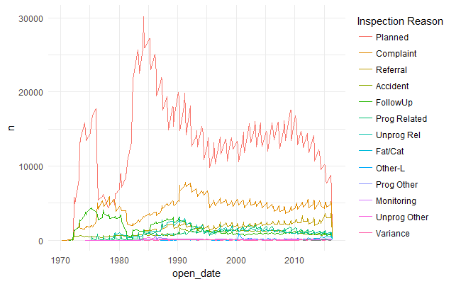

```r
left_join(inspect, inspect_types, by = c("insp_type" = "code")) %>%
            select(value, open_date) %>%
  group_by(open_date = quarter(open_date, with_year = TRUE), value) %>%
  tally %>%
  ggplot(. , aes(x = open_date, y = n, color = fct_reorder2(value, open_date, n))) + geom_line() -> gg
gg + theme_minimal() + labs(color = "Inspection Reason")
```

Hrm. Planned audits have really plummeted. Data not current or are they not being performed? There’s also some big spikes that look to be seasonal.

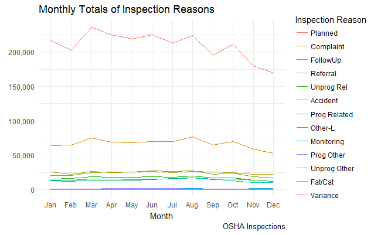

```r
dat <- left_join(inspect, inspect_types, by = c("insp_type" = "code")) %>%
            select(value, open_date) %>%
  mutate(open_date = format(open_date, "%b")) %>%
  group_by(open_date, value) %>%
  tally
dat$open_date <- factor(dat$open_date, levels = month.abb)
dat <- na.omit(dat)
gg <- ggplot(dat , aes(x = open_date, y = n, group = 1))
gg <- gg + stat_summary(fun.y = "sum", geom = "line",
                        aes(group = value, color = fct_reorder2(value, open_date, n)))
gg <- gg + scale_y_continuous(label = comma)
gg + theme_minimal() + labs(color = "Inspection Reason",
                            title = "Monthly Totals of Inspection Reasons",
                            x = "Month",
                            y = element_blank(),
                            caption = "OSHA Inspections")
```

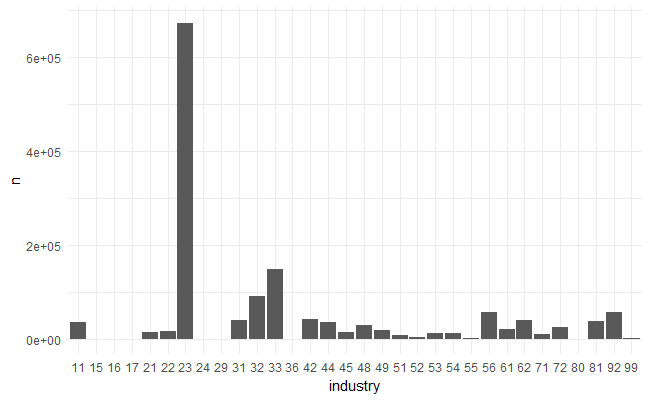

```r
dat <- inspect %>% mutate(industry = as.factor(str_match(naics_code, "(\\d{2})\\d+")[,2])) %>%
  group_by(industry) %>% tally %>% arrange(desc(n)) %>% filter(is.na(industry) == FALSE)
gg <- ggplot(dat, aes(x = industry, y = n))
#gg <- gg + scale_y_log10()
gg <- gg + geom_bar(stat = "identity")
gg <- gg + theme_minimal()
gg
```

Industry code 23 seems super popular. What is it?

> Code 23 is: Construction

Ah, construction. What are all the categories in construction?

```r
naics %>% filter(str_detect(as.character(.$code), "^23"))
```

| naics_title | code |
| --- | --- |
| Construction | 23 |
| Construction of Buildings | 236 |
| Residential Building Construction | 2361 |
| Residential Building Construction | 23611 |
| New Single-Family Housing Construction (except For-Sale Builders) | 236115 |
| New Multifamily Housing Construction (except For-Sale Builders) | 236116 |
| New Housing For-Sale Builders | 236117 |
| Residential Remodelers | 236118 |
| Nonresidential Building Construction | 2362 |
| Industrial Building Construction | 23621 |

[output cut: 63 more lines]

And how many inspections are in each of these construction categories?

```r
inspect %>% filter(str_detect(as.character(.$naics_code), "^23")) %>%
  group_by(naics_code, inspect_year = year(open_date)) %>% summarize(inspections = n()) %>%
  mutate(pct_by_year = percent(inspections / sum(inspections))) %>%
  arrange(desc(inspect_year), desc(inspections)) %>%
  left_join(naics, by = c("naics_code" = "code")) %>%
  select(naics_title, inspect_year, naics_code, everything())
```

| naics_title | inspect_year | naics_code | inspections | pct_by_year |
| --- | --- | --- | --- | --- |
| Roofing Contractors | 2016 | 238160 | 4697 | 5.57% |
| Commercial and Institutional Building Construction | 2016 | 236220 | 3366 | 3.11% |
| Framing Contractors | 2016 | 238130 | 2856 | 5.79% |
| New Single-Family Housing Construction (except For-Sale Builders) | 2016 | 236115 | 1548 | 4.86% |
| Masonry Contractors | 2016 | 238140 | 1351 | 3.12% |
| Plumbing, Heating, and Air-Conditioning Contractors | 2016 | 238220 | 1195 | 3.65% |
| Electrical Contractors and Other Wiring Installation Contractors | 2016 | 238210 | 1160 | 3.13% |
| Highway, Street, and Bridge Construction | 2016 | 237310 | 993 | 3.4% |
| Site Preparation Contractors | 2016 | 238910 | 918 | 3.04% |
| New Multifamily Housing Construction (except For-Sale Builders) | 2016 | 236116 | 862 | 4.9% |

[output cut: 729 more lines]

So commerical and roofing are highly inspected industries.

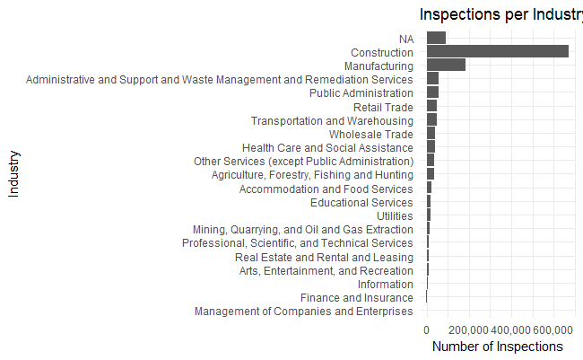

```r
dat <- inspect %>% mutate(industry = str_match(naics_code, "(\\d{2})\\d+")[,2]) %>%
  group_by(industry) %>% tally %>% arrange(desc(n)) %>% filter(is.na(industry) == FALSE)
dat <- left_join(dat, mutate(naics, code = as.character(code)), by = c("industry" = "code")) %>%
  group_by(naics_title) %>% summarize(n = sum(n))
gg <- ggplot(dat, aes(x = fct_reorder(factor(naics_title), n), y = n))
#gg <- gg + scale_y_log10()
gg <- gg + geom_bar(stat = "identity")
gg <- gg + labs(x = "Industry", y = "Number of Inspections", title = "Inspections per Industry")
gg <- gg + scale_y_continuous(label = comma) + coord_flip()
gg <- gg + theme_minimal()
gg
```

### Advanced Notices

How have advanced notices of inspections changed over time?

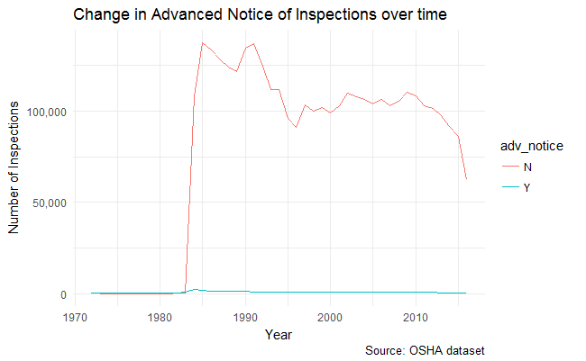

```r
dat <- inspect %>% mutate(yr = year(open_date)) %>%
  group_by(yr, adv_notice) %>% tally() %>% na.omit()
gg <- ggplot(dat, aes(x = yr, y = n, color = adv_notice)) + geom_line() +
  theme_minimal() + labs(title = "Change in Advanced Notice of Inspections over time",
                         caption = "Source: OSHA dataset",
                         x = "Year",
                         y = "Number of Inspections") +
  scale_y_continuous(labels = comma)
gg
```

Interesting. It looks like advanced notice wasn’t tracked, or not given, prior to about 1982. There’s also a big drop of total inspections at the end. We should look at the distribution of inspections over time.

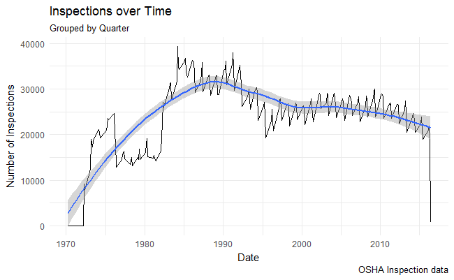

```r
dat <- inspect %>%
  group_by(open_date = quarter(open_date, with_year = TRUE)) %>%
  tally
#gg <- ggplot(inspect, aes(x=open_date, y = n, group=quarter(open_date, with_year = TRUE))) + geom_line(na.rm = TRUE)
#gg <- gg + scale_x_date(date_breaks = "6 months")
gg <- ggplot(dat, aes(x = open_date, y = n)) + geom_line(na.rm = TRUE)
gg <- gg + labs(title = "Inspections over Time",
                subtitle = "Grouped by Quarter",
                caption = "OSHA Inspection data",
                x = "Date",
                y = "Number of Inspections")
gg + theme_minimal() + geom_smooth(method = "loess", na.rm = TRUE)
```

Yup. Inspections are down from the late 80s. They’ve been more or less holding steady over the past decade, though there could be a decreasing trend. The big drop of inspections from 77 - 82 is interesting.

## Violations

Violations have an initial penalty (assessed at the time of report authoring) and a current penalty (presumably a negotiated settlement). Let’s look at these

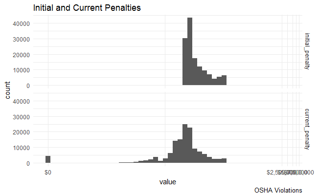

```r
dat <- violations %>%  select(initial_penalty, current_penalty) %>%
  na.omit() %>% filter(initial_penalty > 5473 ) %>%
  mutate(penalty_change = current_penalty - initial_penalty) %>%
  gather(penalty_type)
dat$penalty_type <- factor(dat$penalty_type, levels=c("initial_penalty",
                                                      "current_penalty", "penalty_change"))
gg <- ggplot(filter(dat, as.character(penalty_type) != "penalty_change"), aes(x = value)) + geom_histogram(bins = 50)
#geom_histogram()
#+ facet_grid(penalty_type ~ .)
gg <- gg + scale_x_continuous(trans = "log1p", label=dollar) + facet_grid(penalty_type ~ .)
gg <- gg + labs(title = "Initial and Current Penalties", caption = "OSHA Violations")
gg + theme_minimal()
```

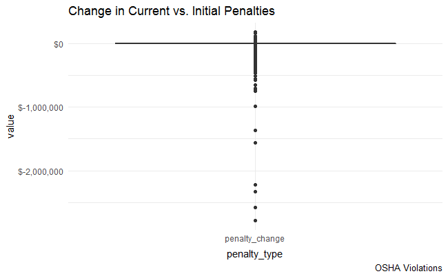

```r
gg <- ggplot(filter(dat, as.character(penalty_type) == "penalty_change"), aes(x = penalty_type, y = value))
gg <- gg + geom_boxplot()
gg <- gg + scale_y_continuous(label = dollar)
gg <- gg + labs(title = "Change in Current vs. Initial Penalties", caption = "OSHA Violations")
gg + theme_minimal()
```